# DDSAnalytics – Frito Lay Employee Attrition Case Study

Bronson Pada

2026-10-30

## Introduction

This case study examines employee attrition at Frito Lay using data provided by DDSAnalytics.

## Exploratory Data Analysis

The dataset contains 870 employees, including 730 who stayed and 140 who left the company.

```r
# Employee attrition summary
total_employees <- 870
employees_left <- 140
employees_stayed <- 730

round(100 * employees_left / total_employees, 2)
```

```
## [1] 16.09
```

## Factors Associated with Employee Attrition

Exploratory data analysis identified three factors associated with higher employee attrition: job involvement, work-life balance, and overtime.

Employees with low job involvement had an attrition rate of 46.81%. Employees with poor work-life balance had an attrition rate of 35.42%, and employees who worked overtime had an attrition rate of 31.75%.

```r
# Count employees by Job Involvement and Attrition
table(
  employee_data$JobInvolvement,
  employee_data$Attrition
)
```

```
##
##      No Yes
##   1  25  22
##   2 184  44
##   3 447  67
##   4  74   7
```

```r
# Calculate attrition percentages
round(
  prop.table(
    table(
      employee_data$JobInvolvement,
      employee_data$Attrition
    ),
    margin = 1
  ) * 100,
  2
)
```

```
##
##        No   Yes
##   1 53.19 46.81
##   2 80.70 19.30
##   3 86.96 13.04
##   4 91.36  8.64
```

## Work-Life Balance and Employee Attrition

The analysis examines how work-life balance is associated with employee attrition.

```r
# Count employees by Work-Life Balance and Attrition
table(
  employee_data$WorkLifeBalance,
  employee_data$Attrition
)
```

```
##
##      No Yes
##   1  31  17
##   2 162  30
##   3 452  80
##   4  85  13
```

```r
# Calculate attrition percentages
round(
  prop.table(
    table(
      employee_data$WorkLifeBalance,
      employee_data$Attrition
    ),
    margin = 1
  ) * 100,
  2
)
```

```
##
##        No   Yes
##   1 64.58 35.42
##   2 84.38 15.62
##   3 84.96 15.04
##   4 86.73 13.27
```

## Overtime and Employee Attrition

This analysis examines whether employees who work overtime have higher attrition rates than employees who do not work overtime.

```r
# Count employees by Overtime and Attrition
table(
  employee_data$OverTime,
  employee_data$Attrition
)
```

```
##
##        No Yes
##   No  558  60
##   Yes 172  80
```

```r
# Calculate attrition percentages
round(
  prop.table(
    table(
      employee_data$OverTime,
      employee_data$Attrition
    ),
    margin = 1
  ) * 100,
  2
)
```

```
##
##          No   Yes
##   No  90.29  9.71
##   Yes 68.25 31.75
```

## Classification Model Comparison

Two classification models, k-Nearest Neighbors (k-NN) and Naive Bayes, were evaluated to predict employee attrition.

The models were compared using accuracy, sensitivity, and specificity on a test dataset containing 261 employees.

The adjusted Naive Bayes model achieved 74.33% accuracy, 69.05% sensitivity, and 75.34% specificity.

The adjusted k-NN model achieved 48.66% accuracy, 85.71% sensitivity, and 41.55% specificity.

Naive Bayes provided better overall accuracy and specificity, while k-NN identified a higher percentage of employees who actually left.

```r
# Model comparison using held-out test results

model_comparison <- data.frame(
  Model = c("k-NN", "Naive Bayes"),
  Accuracy = c(48.66, 74.33),
  Sensitivity = c(85.71, 69.05),
  Specificity = c(41.55, 75.34)
)

# Display comparison table
knitr::kable(
  model_comparison,
  caption = "Classification Model Performance (%)"
)
```

Classification Model Performance (%)

| Model | Accuracy | Sensitivity | Specificity |
| --- | --- | --- | --- |
| k-NN | 48.66 | 85.71 | 41.55 |
| Naive Bayes | 74.33 | 69.05 | 75.34 |

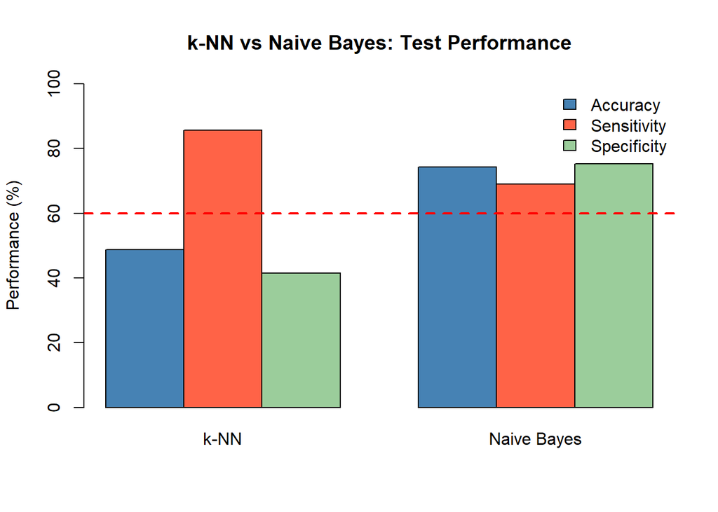

```r
# Generate comparison chart
comparison_matrix <- t(
  as.matrix(model_comparison[, 2:4])
)

colnames(comparison_matrix) <- model_comparison$Model

barplot(
  comparison_matrix,
  beside = TRUE,
  col = c("steelblue", "tomato", "darkseagreen3"),
  ylim = c(0, 100),
  main = "k-NN vs Naive Bayes: Test Performance",
  ylab = "Performance (%)",
  legend.text = rownames(comparison_matrix),
  args.legend = list(x = "topright", bty = "n")
)

abline(h = 60, col = "red", lty = 2, lwd = 2)
```

## Confusion Matrices: Predicted vs. Actual Attrition

Confusion matrices were used to evaluate how accurately the k-NN and Naive Bayes models classified employee attrition.

The test dataset contained 261 employees, including 219 employees who stayed and 42 employees who left.

The adjusted k-NN model used a 10% probability threshold, while the adjusted Naive Bayes model used a 20% probability threshold.

```r
# Confusion matrices from held-out test results
# Rows = Predicted, Columns = Actual

knn_matrix <- matrix(
  c(91, 128, 6, 36),
  nrow = 2,
  dimnames = list(
    Predicted = c("Stayed", "Left"),
    Actual = c("Stayed", "Left")
  )
)

nb_matrix <- matrix(
  c(165, 54, 13, 29),
  nrow = 2,
  dimnames = list(
    Predicted = c("Stayed", "Left"),
    Actual = c("Stayed", "Left")
  )
)

# Display k-NN confusion matrix
knitr::kable(
  knn_matrix,
  caption = "k-NN Confusion Matrix (10% Threshold)"
)
```

k-NN Confusion Matrix (10% Threshold)

|  | Stayed | Left |
| --- | --- | --- |
| Stayed | 91 | 6 |
| Left | 128 | 36 |

```r
# Display Naive Bayes confusion matrix
knitr::kable(
  nb_matrix,
  caption = "Naive Bayes Confusion Matrix (20% Threshold)"
)
```

Naive Bayes Confusion Matrix (20% Threshold)

|  | Stayed | Left |
| --- | --- | --- |
| Stayed | 165 | 13 |
| Left | 54 | 29 |

## Financial Impact of Employee Attrition

Employee attrition creates potential replacement costs for the organization. This analysis estimates replacement costs using the average monthly income of employees who left the company.

The average monthly income of employees who left was approximately $4,764.79, equivalent to an estimated annual salary of $57,177.43.

Replacement costs are evaluated using hypothetical scenarios of 50%, 100%, 200%, and 400% of annual salary.

```r
# Financial Impact: Replacement Cost Scenarios

# Average monthly income of employees who left
average_monthly_income <- 4764.786

# Estimate annual salary
annual_salary <- average_monthly_income * 12

# Replacement cost scenarios
replacement_rates <- c(0.50, 1.00, 2.00, 4.00)

replacement_costs <- annual_salary * replacement_rates

# Create comparison table
replacement_table <- data.frame(
  Replacement_Cost = c("50%", "100%", "200%", "400%"),
  Cost_Per_Employee = round(replacement_costs, 2)
)

# Display results
knitr::kable(
  replacement_table,
  caption = "Estimated Employee Replacement Costs"
)
```

Estimated Employee Replacement Costs

| Replacement_Cost | Cost_Per_Employee |
| --- | --- |
| 50% | 28588.72 |
| 100% | 57177.43 |
| 200% | 114354.86 |
| 400% | 228709.73 |

## Retention Program Break-Even and Potential Savings

This analysis estimates how many employee departures must be prevented to recover the cost of a proposed retention program.

```r
# Retention program investment
total_employees <- 870
program_cost_per_employee <- 200
total_program_cost <- total_employees * program_cost_per_employee

# Calculate break-even departures
break_even_departures <- ceiling(
  total_program_cost / replacement_costs
)

# Calculate potential net savings
net_savings <- (break_even_departures * replacement_costs) -
  total_program_cost

# Create break-even table
break_even_table <- data.frame(
  Replacement_Scenario = c("50%", "100%", "200%", "400%"),
  Break_Even_Departures = break_even_departures,
  Potential_Net_Savings = round(net_savings, 2)
)

# Display results
knitr::kable(
  break_even_table,
  caption = "Retention Program Break-Even and Potential Net Savings"
)
```

Retention Program Break-Even and Potential Net Savings

| Replacement_Scenario | Break_Even_Departures | Potential_Net_Savings |
| --- | --- | --- |
| 50% | 7 | 26121.01 |
| 100% | 4 | 54709.73 |
| 200% | 2 | 54709.73 |
| 400% | 1 | 54709.73 |

## Conclusions and Recommendations

### Key Findings

The analysis examined employee attrition among 870 employees. Of these employees, 140 left the company and 730 stayed, resulting in an overall attrition rate of 16.09%.

Three employee characteristics were associated with higher attrition:

- Employees with low job involvement (rating 1) had an attrition rate of 46.81%.
- Employees with poor work-life balance (rating 1) had an attrition rate of 35.42%.
- Employees who worked overtime had an attrition rate of 31.75%.

These findings suggest that employee engagement, work-life balance, and overtime should be priorities for further investigation.

### Classification Model Results

Two classification models were evaluated using a test dataset of 261 employees.

The adjusted Naive Bayes model achieved 74.33% accuracy, 69.05% sensitivity, and 75.34% specificity.

The adjusted k-Nearest Neighbors (k-NN) model achieved 48.66% accuracy, 85.71% sensitivity, and 41.55% specificity.

Naive Bayes provided better overall accuracy and specificity, while k-NN identified a greater percentage of employees who actually left.

Both models had lower overall accuracy than predicting that every employee would stay (83.91%). However, that simple approach would fail to identify any employees who left.

### Financial Impact

The estimated annual salary of employees who left was approximately $57,177.43.

Employee replacement costs were evaluated using hypothetical scenarios ranging from 50% to 400% of annual salary.

A proposed retention program costing $200 per employee would require a total investment of $174,000.

Under the 50% replacement-cost scenario, preventing seven employee departures would recover the program investment and generate approximately $26,121 in potential net savings.

These savings are hypothetical and depend on the retention program actually preventing employee departures.

### Recommendations

1. Investigate low job involvement and identify opportunities to improve employee engagement.
2. Review employee workloads and work-life balance to identify potential retention improvements.
3. Evaluate overtime practices, particularly among employees experiencing consistently high workloads.
4. Consider using Naive Bayes as a balanced screening model and k-NN when identifying more potential leavers is the priority, while accounting for false-positive predictions.
5. Implement a small employee retention pilot program and measure its effectiveness before expanding the investment.

### Final Conclusion

Employee attrition represents a potential financial and operational challenge for the organization.

The analysis identified employee groups associated with elevated attrition and demonstrated how classification models can support retention planning.

Combining employee engagement initiatives, predictive analytics, and financial evaluation may help the organization make more informed employee retention decisions.